# **AllLife Bank Customer Segmentation**

## **Background**

AllLife Bank (ALB) wants to focus on its credit card customer base in the next financial year. ALB has been advised by its marketing research team (MRT), that the market penetration can be improved. Based on this premise, the Marketing team proposes to run personalized campaigns to target new customers as well as upsell to existing customers. Another insight from the MRT was that customers perceive the support services of ALB poorly. Considering these, the Operations team wants to improve the service delivery model to ensure that customer queries are resolved faster. The head of Marketing and the head of Delivery decide to reach out to the Data Science team for help.

## **Problem Definition**

Credit Card services present these problems:

- Market Penetration has to increase.
- Current Customer's Credit Card Services should increase.
- Credit Card Customer Support is perceived as poor.
- Credit Card Customer's Queries should be resolved faster.

## **Objectives**

1. Identify (classify) the different segments in the existing customer base, based on their spending patterns, past interaction with the bank, and any other important data available.
2. Specify the characteristics of each segment and notice the weak or strong patterns of each segment.
3. Provide recommendations to ALB for each segment based on items 1 and 2 above. These recommendations should include how to expand the market penetration (new and current customers) and how to improve the customer services. Possibly recommend what type of service feature is important for each segment.

## **Data Available**

The data provided is of various customers of ALB and their financial attributes like credit limit, the total number of credit cards the customer has, and different channels through which customers have contacted the bank for any queries (including visiting the bank, online and through a call center).

**Data Dictionary**

- Sl_No: Primary key of the records
- Customer Key: Customer identification number
- Average Credit Limit: Average credit limit of each customer for all credit cards
- Total credit cards: Total number of credit cards possessed by the customer
- Total visits bank: Total number of visits that customer made (yearly) personally to the bank
- Total visits online: Total number of visits or online logins made by the customer (yearly)
- Total calls made: Total number of calls made by the customer to the bank or its customer service department (yearly)

## **Questions**

Formulating Questions after knowing what type of data is available help us formulate better questions.

Q1. How can the customers be grouped/segmented (classified)?

Q2. What are the commonalities of each group/segment? ie:

- Total/Particular Interaction w/ ALB
- Total Credit Cards
- Average Credit Limit

Q3. What is the group/segment that has most/least interactions/particular type of interaction with ALB?

Q4. Is there a relationship between Average Credit Limit/Total Credit Cards and customer satisfaction (assuming that the number of interactions is an indication of unsolved issues).

Q5. What is the relationship between Average Credit Limit/Total Credit Cards to interactions/type of interactions with ALB (this question is partially addressed by Q2).

Q6. What recommendations can be made for each group/segment to improve customer satisfaction (assuming that the number of interactions is an indication of unsolved issues).

Q7. What recommendations can be made based in segment characteristics to increase market penetration/expand services to current customers?

With these set of questions, we address the problems introduced earlier and make recommendations to ALB.

## **Technique**

This is a unsupervised classification problem. We will classify customers into different segments using K-means Clustering and Hierarchical Clustering algorithms.

1. Perform the data preprocessing, EDA analysis, and feature engineering. We will visualize features and observe relationships performing a uni and bivariate analysis.
2. Attempt the classification using the K-means clustering. We will estimate the better number of clusters using the elbow method and observe silhouettes. Then we will visualize the clusters.
3. Attempt the classification using the hierarchical clustering. We will explore clustering with different linkage methods (i.e. single, complete, etc) and distances (i.e. euclidean, manhattan, etc) reviewing the cophenetic correlation and find the ideal number of clusters. Then we will visualize the clusters.
4. Compare K-means vs Hierachical clustering results.

## Setup

```python
#yellowbrick is a machine learning visualization library. We will use it to
#visualize the cluster silhouettes.
!pip install yellowbrick
```

```python
# Avoids scroll-in-the-scroll in the entire Notebook
from IPython.display import Javascript
def resize_colab_cell():
  display(Javascript('google.colab.output.setIframeHeight(0, true, {maxHeight: 5000})'))
get_ipython().events.register('pre_run_cell', resize_colab_cell)
```

```python
#import libraries

#ignoring warnings
import warnings
warnings.filterwarnings("ignore")

# to round floor, ceil
#from math import floor, ceil

from array import *

#importing necessary libraries
import pandas as pd
import numpy as np
import seaborn as sns
import matplotlib.pyplot as plt
import matplotlib.cm as cm
import os

#KN clustering
from sklearn.cluster import KMeans, AgglomerativeClustering
from scipy.cluster.hierarchy import cophenet, dendrogram, linkage
import scipy.cluster.hierarchy as shc

from scipy.stats import zscore

# to compute distances
from scipy.spatial.distance import cdist, pdist
from sklearn.metrics import silhouette_score, silhouette_samples

from sklearn.decomposition import PCA

# to visualize the elbow curve and silhouette scores
from yellowbrick.cluster import KElbowVisualizer, SilhouetteVisualizer

# To impute missing values
#from sklearn.impute import SimpleImputer

# to scale the data using z-score
from sklearn.preprocessing import StandardScaler

# to create k folds of data and get cross validation score
#from sklearn.model_selection import KFold, StratifiedKFold
#from sklearn.model_selection import cross_val_score

# to use standard scaler
from sklearn.preprocessing import StandardScaler

#restrict float value to 3 decimal places
pd.set_option('display.float_format',lambda x: '%.3f' % x)
%matplotlib inline
```

```python
#allow access to google drive
from google.colab import drive
drive.mount('/content/gdrive')
```

```python
#read csv file and load into a panda dataframe
ALB_orig_df = pd.read_excel('/content/gdrive/MyDrive/UT-ML/Project6/Credit+Card+Customer+Data.xlsx')
```

```python
#copy original data frame
ALB_df = ALB_orig_df.copy()
```

## Functions

```python
#Useful functions for this notebook

#Function to show %
def autopct_format(values):
        def my_format(pct):
            total = sum(values)
            val = int(round(pct*total/100.0))
            return '{:.1f}%\n({v:d})'.format(pct, v=val)
        return my_format

# function to create labeled barplots
def labeled_barplot(data, feature, perc=False, n=None):
    """
    Barplot with percentage at the top

    data: dataframe
    feature: dataframe column
    perc: whether to display percentages instead of count (default is False)
    n: displays the top n category levels (default is None, i.e., display all levels)
    """

    total = len(data[feature])  # length of the column
    count = data[feature].nunique()
    if n is None:
        plt.figure(figsize=(count + 2, 6))
    else:
        plt.figure(figsize=(n + 2, 6))

    plt.xticks(rotation=90, fontsize=15)
    ax = sns.countplot(
        data=data,
        x=feature,
        palette="Paired",
        order=data[feature].value_counts().index[:n],
    )

    for p in ax.patches:
        if perc == True:
            label = "{:.1f}%".format(
                100 * p.get_height() / total
            )  # percentage of each class of the category
        else:
            label = p.get_height()  # count of each level of the category

        x = p.get_x() + p.get_width() / 2  # width of the plot
        y = p.get_height()  # height of the plot

        ax.annotate(
            label,
            (x, y),
            ha="center",
            va="center",
            size=12,
            xytext=(0, 5),
            textcoords="offset points",
        )  # annotate the percentage

    plt.show()  # show the plot

#function to create histograms and boxplots at once
def histogram_boxplot(data, feature, figsize=(15, 10), kde=False, bins=None):
    """
    Boxplot and histogram combined

    data: dataframe
    feature: dataframe column
    figsize: size of figure (default (15,10))
    kde: whether to show the density curve (default False)
    bins: number of bins for histogram (default None)
    """
    f2, (ax_box2, ax_hist2) = plt.subplots(
        nrows=2,  # Number of rows of the subplot grid= 2
        sharex=True,  # x-axis will be shared among all subplots
        gridspec_kw={"height_ratios": (0.25, 0.75)},
        figsize=figsize,
    )  # creating the 2 subplots
    sns.boxplot(
        data=data, x=feature, ax=ax_box2, showmeans=True, color="violet"
    )  # boxplot will be created and a triangle will indicate the mean value of the column
    sns.histplot(
        data=data, x=feature, kde=kde, ax=ax_hist2, bins=bins
    ) if bins else sns.histplot(
        data=data, x=feature, kde=kde, ax=ax_hist2
    )  # For histogram
    ax_hist2.axvline(
        data[feature].mean(), color="green", linestyle="--"
    )  # Add mean to the histogram
    ax_hist2.axvline(
        data[feature].median(), color="black", linestyle="-"
    )  # Add median to the histogram

# function to plot stacked bar chart
def stacked_barplot(data, predictor, target):
    """
    Print the category counts and plot a stacked bar chart

    data: dataframe
    predictor: independent variable
    target: target variable
    """
    count = data[predictor].nunique()
    sorter = data[target].value_counts().index[-1]
    tab1 = pd.crosstab(data[predictor], data[target], margins=True).sort_values(
        by=sorter, ascending=False
    )
    print(tab1)
    print("-" * 120)
    tab = pd.crosstab(data[predictor], data[target], normalize="index").sort_values(
        by=sorter, ascending=False
    )
    tab.plot(kind="bar", stacked=True, figsize=(count + 1, 5))
    plt.legend(
        loc="lower left",
        frameon=False,
    )
    plt.legend(loc="upper left", bbox_to_anchor=(1, 1))
    plt.show()

#Function to visualize the clusters using pca
def visualize_clusters(data, number_components, number_clusters):
    """
    data: dataframe
    number_components: the number of components to perform principal component analysis
    number of clusters: how many clusters are visualized
    """
    #set data to number_dimensions
    pca=PCA(number_components)

    #transform the data
    pca_df = pca.fit_transform(data)

    #redo kmeans
    kmeans_pca = KMeans(n_clusters=number_clusters)

    #predict labels
    label = kmeans_pca.fit_predict(pca_df)

    #Get unique labels
    u_labels = np.unique(label)

    #Getting the Centroids
    centroids = kmeans_pca.cluster_centers_

    #plotting the results:

    titleLabel = "Cluster Plot Kn = "+ str(number_clusters)

    plt.title(titleLabel)
    for i in u_labels:
      plt.scatter(pca_df[label == i , 0] , pca_df[label == i , 1] , label = i)
      plt.scatter(centroids[:,0] , centroids[:,1] , s = 80, color = 'k')

    plt.legend()
    plt.show()

#Function to visualize the clusters using pca for hc
def visualize_hc_clusters(data, number_components, number_clusters):
    """
    data: dataframe
    number_components: the number of components to perform principal component analysis
    number of clusters: how many clusters are visualized
    """
    #set data to number_dimensions
    pca=PCA(number_components)

    #transform the data
    pca_df = pca.fit_transform(data)

    #redo hca
    hca_pca = AgglomerativeClustering(n_clusters=number_clusters, affinity="euclidean", linkage="average")
    hca_pca.fit(ALB_scaled_df)

    #predict labels
    label = hca_pca.fit_predict(pca_df)

    #Get unique labels
    u_labels = np.unique(label)

     #plotting the results:

    titleLabel = "Cluster Plot Hierachical Clustering number of clusters = "+ str(number_clusters)

    plt.title(titleLabel)
    for i in u_labels:
      plt.scatter(pca_df[label == i , 0] , pca_df[label == i , 1] , label = i)

    plt.legend()
    plt.show()


#function to plot dendrogram
def plotDendrogram(*Z,leafrotation,colorthreshold,leafontsize):
    """
    *Z: array
    leafrotation: vertical or horizontal
    colorthreshold: colors
    leafontsize: size of font
    """
    plt.figure(figsize=(10, 5))
    plt.title('Agglomerative Hierarchical Clustering Dendogram')
    plt.xlabel('sample index')
    plt.ylabel('Distance')
    dendrogram(Z, leafrotation, colorthreshold, leafontsize)
    plt.tight_layout()

def dendrogram_single_plot(data, d_method, d_metric, y_dist):
  plt.figure(figsize=(10, 7))
  title_label = "Dendrogram for method: " + d_method + " metric: "+d_metric +" distance : "+ str(y_dist)
  plt.title(title_label)

  # Selecting method and metric by index
  clusters = shc.linkage(data,
            method=d_method,
            metric=d_metric)
  shc.dendrogram(Z=clusters)
  plt.axhline(y = y_dist, color = 'black', linestyle = '-')
```

## **Data Preprocessing**

### **Quick** Analysis

```python
#Check number of rows and columns
ALB_df.shape
```

```
(660, 7)
```

660 rows, 7 features

```python
#Lets take a look at the dataset characteristics
ALB_df.info()
```

```
<class 'pandas.core.frame.DataFrame'>
RangeIndex: 660 entries, 0 to 659
Data columns (total 7 columns):
 #   Column               Non-Null Count  Dtype
---  ------               --------------  -----
 0   Sl_No                660 non-null    int64
 1   Customer Key         660 non-null    int64
 2   Avg_Credit_Limit     660 non-null    int64
 3   Total_Credit_Cards   660 non-null    int64
 4   Total_visits_bank    660 non-null    int64
 5   Total_visits_online  660 non-null    int64
 6   Total_calls_made     660 non-null    int64
dtypes: int64(7)
memory usage: 36.2 KB
```

Notice that there are no null values. Also that all data types are numeric.

```python
#lets examine the head
ALB_df.head(10)
```

|  | Sl_No | Customer Key | Avg_Credit_Limit | Total_Credit_Cards | Total_visits_bank | Total_visits_online | Total_calls_made |
| --- | --- | --- | --- | --- | --- | --- | --- |
| 0 | 1 | 87073 | 100000 | 2 | 1 | 1 | 0 |
| 1 | 2 | 38414 | 50000 | 3 | 0 | 10 | 9 |
| 2 | 3 | 17341 | 50000 | 7 | 1 | 3 | 4 |
| 3 | 4 | 40496 | 30000 | 5 | 1 | 1 | 4 |
| 4 | 5 | 47437 | 100000 | 6 | 0 | 12 | 3 |
| 5 | 6 | 58634 | 20000 | 3 | 0 | 1 | 8 |
| 6 | 7 | 48370 | 100000 | 5 | 0 | 11 | 2 |
| 7 | 8 | 37376 | 15000 | 3 | 0 | 1 | 1 |
| 8 | 9 | 82490 | 5000 | 2 | 0 | 2 | 2 |
| 9 | 10 | 44770 | 3000 | 4 | 0 | 1 | 7 |

Notice that out of the 7 features, the first two 'Sl_No' and "Customer Key" are not useful in our analysis. Also notice that the third feature "Avg_Credit_Limit" has values that are very large compared to the rest of the dataset. We anticipate the need to scale the data.

### **Null Values**

```python
#Checking missing values
ALB_df.isna().sum()
```

```
Sl_No                  0
Customer Key           0
Avg_Credit_Limit       0
Total_Credit_Cards     0
Total_visits_bank      0
Total_visits_online    0
Total_calls_made       0
dtype: int64
```

Verifying that there No Nulls.

### **Duplicated entries**

```python
#Duplicated entries (exact entries or 2 or more rows are exactly the same)
ALB_df.duplicated().sum()
```

```
0
```

There are no duplicated entries (exact same contents in more than one entry)

```python
#Duplicated Customers (Customer Key)?
ALB_df['Customer Key'].duplicated().sum()
```

```
5
```

There are five duplicated customer keys, which represent 0.8% of all data. Lets check them out.

```python
ALB_dupKey = ALB_df[ALB_df.duplicated(["Customer Key"], False)]
ALB_dupKey.sort_values(by=['Customer Key'])
```

|  | Sl_No | Customer Key | Avg_Credit_Limit | Total_Credit_Cards | Total_visits_bank | Total_visits_online | Total_calls_made |
| --- | --- | --- | --- | --- | --- | --- | --- |
| 48 | 49 | 37252 | 6000 | 4 | 0 | 2 | 8 |
| 432 | 433 | 37252 | 59000 | 6 | 2 | 1 | 2 |
| 4 | 5 | 47437 | 100000 | 6 | 0 | 12 | 3 |
| 332 | 333 | 47437 | 17000 | 7 | 3 | 1 | 0 |
| 411 | 412 | 50706 | 44000 | 4 | 5 | 0 | 2 |
| 541 | 542 | 50706 | 60000 | 7 | 5 | 2 | 2 |
| 391 | 392 | 96929 | 13000 | 4 | 5 | 0 | 0 |
| 398 | 399 | 96929 | 67000 | 6 | 2 | 2 | 2 |
| 104 | 105 | 97935 | 17000 | 2 | 1 | 2 | 10 |
| 632 | 633 | 97935 | 187000 | 7 | 1 | 7 | 0 |

The duplicate "Customer Key" may very well be different account snapshots over time. We don't have a time feature but notice that the number of "Total_Credit_Cards" change (and other features changed too). So we consider these different valid entries.

We conclude that there are NO duplicated entries in the data. Even if we drop "Sl_No" and "Customer Key" and we encounter exact duplicated entries, these are valid entries that correspond to different customers or are one of the 5 customers with more than one entry (actually checking the duplicated entries above, we know it is not the case) that represent snapshots of the customer at different times.

Therefore, there are no Duplicate Entries.

### **No Contribution Features**

As we explained earlier, "Sl_No" and "Customer Key" do not contribute any valuable information to our classification (unless of course we choose the number of clusters = number of customers!).

We will drop from our dataset:

- Sl_No: Primary key of the records
- Customer Key: Customer identification number

```python
#Drop first two columns
coltodrop = ['Sl_No','Customer Key']
ALB_df.drop(coltodrop, axis=1,inplace=True)
```

```python
#verify that the columns were dropped
ALB_df.info()
```

```
<class 'pandas.core.frame.DataFrame'>
RangeIndex: 660 entries, 0 to 659
Data columns (total 5 columns):
 #   Column               Non-Null Count  Dtype
---  ------               --------------  -----
 0   Avg_Credit_Limit     660 non-null    int64
 1   Total_Credit_Cards   660 non-null    int64
 2   Total_visits_bank    660 non-null    int64
 3   Total_visits_online  660 non-null    int64
 4   Total_calls_made     660 non-null    int64
dtypes: int64(5)
memory usage: 25.9 KB
```

The features "Sl_No" and "Customer Key" were dropped successfully.

### **Missing Values**

We know that there are no Null values in the data. However, what if there are invalid entries that pose as numbers? Lets check.

```python
#Check "Avg_Credit_Limit"
ALB_df['Avg_Credit_Limit'].value_counts()
```

```
8000      35
6000      31
9000      28
13000     28
19000     26
          ..
43000      1
146000     1
155000     1
200000     1
167000     1
Name: Avg_Credit_Limit, Length: 110, dtype: int64
```

```python
#Check if there is a negative entry for "Avg_Credit_Limit"
AvgCreditNeg = ALB_df[ALB_df['Avg_Credit_Limit']<0]
AvgCreditNeg
```

|  | Avg_Credit_Limit | Total_Credit_Cards | Total_visits_bank | Total_visits_online | Total_calls_made |
| --- | --- | --- | --- | --- | --- |

No negative entries for "Avg_Credit_Limit". The entries are correct.

```python
#Check "Total_Credit_Cards"
ALB_df['Total_Credit_Cards'].value_counts()
```

```
4     151
6     117
7     101
5      74
2      64
1      59
3      53
10     19
9      11
8      11
Name: Total_Credit_Cards, dtype: int64
```

"Total_Credit_Cards" are all numerical and positive. The entries are valid values.

```python
#Check "Total_visits_bank"
ALB_df['Total_visits_bank'].value_counts()
```

```
2    158
1    112
0    100
3    100
5     98
4     92
Name: Total_visits_bank, dtype: int64
```

"Total_visits_bank" are all numerical and positive. The entries are valid values.

```python
#Check "Total_visits_online"
ALB_df['Total_visits_online'].value_counts()
```

```
2     189
0     144
1     109
4      69
5      54
3      44
15     10
7       7
10      6
12      6
8       6
11      5
13      5
9       4
14      1
6       1
Name: Total_visits_online, dtype: int64
```

"Total_visits_online" are all numerical and positive. The entries are valid values.

```python
#Check "Total_calls_made"
ALB_df['Total_calls_made'].value_counts()
```

```
4     108
0      97
2      91
1      90
3      83
6      39
7      35
9      32
8      30
5      29
10     26
Name: Total_calls_made, dtype: int64
```

"Total_calls_made" are all numerical and positive. The entries are valid values.

All values are correct, and there are no missing values.

## **EDA**

After treating missing values (none), null values (none), duplicated values (none) and dropping non contributing features, lets check the data again.

```python
#General statistics of the data
ALB_df.describe().T
```

|  | count | mean | std | min | 25% | 50% | 75% | max |
| --- | --- | --- | --- | --- | --- | --- | --- | --- |
| Avg_Credit_Limit | 660.000 | 34574.242 | 37625.488 | 3000.000 | 10000.000 | 18000.000 | 48000.000 | 200000.000 |
| Total_Credit_Cards | 660.000 | 4.706 | 2.168 | 1.000 | 3.000 | 5.000 | 6.000 | 10.000 |
| Total_visits_bank | 660.000 | 2.403 | 1.632 | 0.000 | 1.000 | 2.000 | 4.000 | 5.000 |
| Total_visits_online | 660.000 | 2.606 | 2.936 | 0.000 | 1.000 | 2.000 | 4.000 | 15.000 |
| Total_calls_made | 660.000 | 3.583 | 2.865 | 0.000 | 1.000 | 3.000 | 5.000 | 10.000 |

Lets see what all this means performing a univariate analysis.

### **Univariate Analysis**

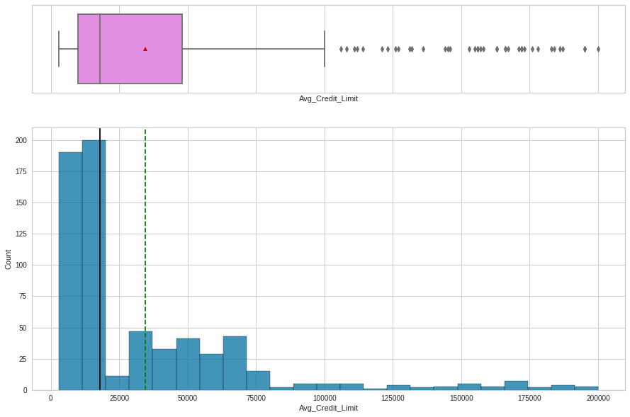

```python
#Analyze "Avg_Credit_Limit"
histogram_boxplot(ALB_df, "Avg_Credit_Limit")
```

```python
acl_median = ALB_df['Avg_Credit_Limit'].median()
print("Avg_Credit_Limit median = ",acl_median)
```

```
Avg_Credit_Limit median =  18000.0
```

Notice that the distribution is skewed to the right (positively skewed). The median is \$18,000, and the mean is \$34,574. There are many outliers above \$100,000.

Are these outliers valid? In a bank, there will be customers that fall within the range of the outliers. There will be customers that have large average credit limits. Also, notice that this may be related to the number of credit cards a customer has.

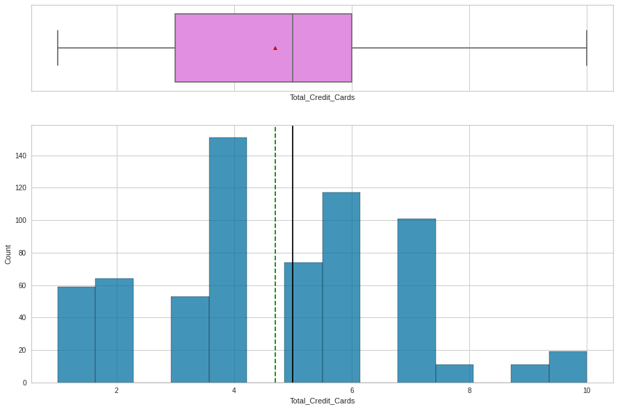

```python
#Analyze "Total_Credit_Cards"
histogram_boxplot(ALB_df, "Total_Credit_Cards")
```

```python
tcc_median = ALB_df['Total_Credit_Cards'].median()
print("Total_Credit_Cards median = ",tcc_median)
```

```
Total_Credit_Cards median =  5.0
```

"Total_Credit_Cards" is skewed left (negative skew).

The median is 5, the mean is 4.7, 25%(Q1) of the data has 3 cards or less and 25%(Q3) has 6 cards or more.

There are no outliers.

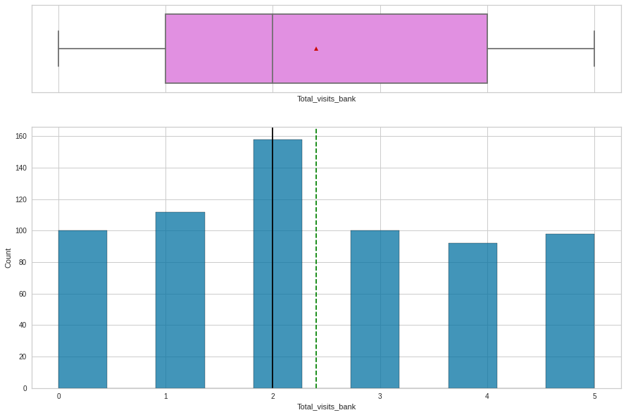

```python
#Analyze "Total_visits_bank"
histogram_boxplot(ALB_df, "Total_visits_bank")
```

```python
tvb_median = ALB_df['Total_visits_bank'].median()
print("Total_visits_bank median = ",tvb_median)
```

```
Total_visits_bank median =  2.0
```

"Total_visits_bank" is skewed to the right (positive skew).

How shoule we treat the outliers? In a bank, there will always be customers that visit the bank many times above the average.

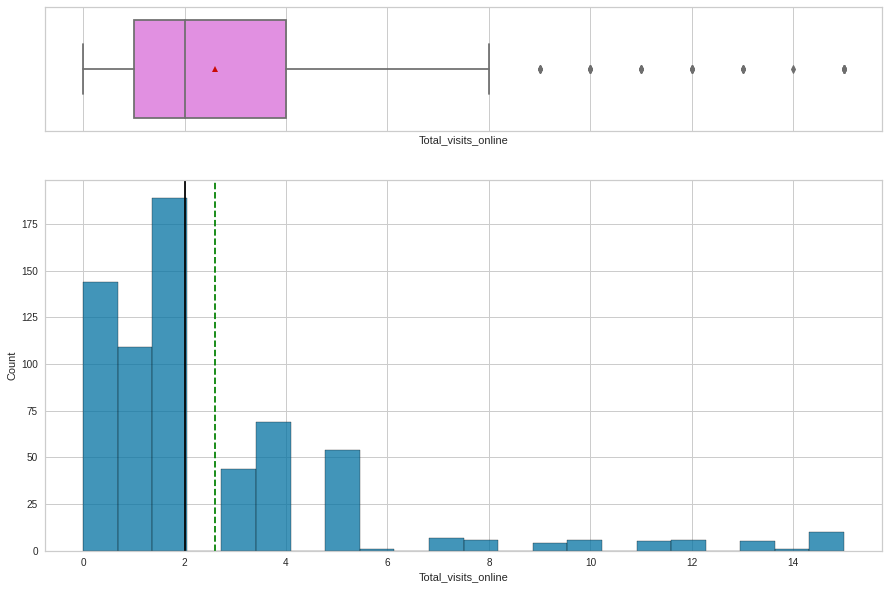

```python
#Analyze "Total_visits_online"
histogram_boxplot(ALB_df, "Total_visits_online")
```

```python
tvo_median = ALB_df['Total_visits_online'].median()
print("Total_visits_online median = ",tvo_median)
```

```
Total_visits_online median =  2.0
```

"Total_visits_online" is skewed to the right (Positive skew). It has a median of 2 and a mean of about 2.6.

25% (Q1) make 1 visit online or less, and 25% (Q3) make 4 visits online or more.

There are outliers above 8. But a bank will always experience many customers that make countless visits online.

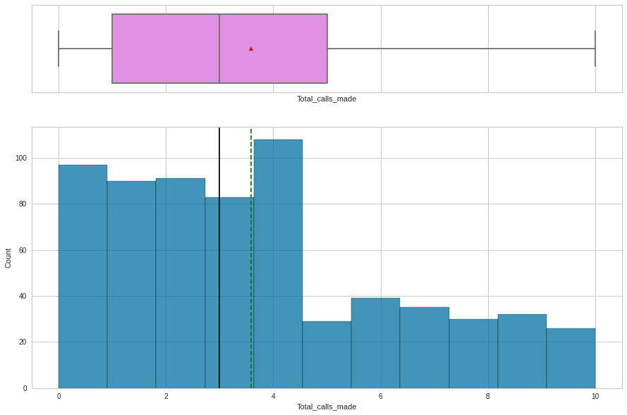

```python
#Analyze "Total_calls_made"
histogram_boxplot(ALB_df, "Total_calls_made")
```

```python
tcm_median = ALB_df['Total_calls_made'].median()
print("Total_calls_made median = ",tcm_median)
```

```
Total_calls_made median =  3.0
```

This resembles more a normal distribution compared to all other features, and it is skewed to the right.

The median is 3, mean is 3.5, 25%(Q1) make 1 phone call or less, and 25%(Q3) make 5 or more phone calls.

There are no outliers.

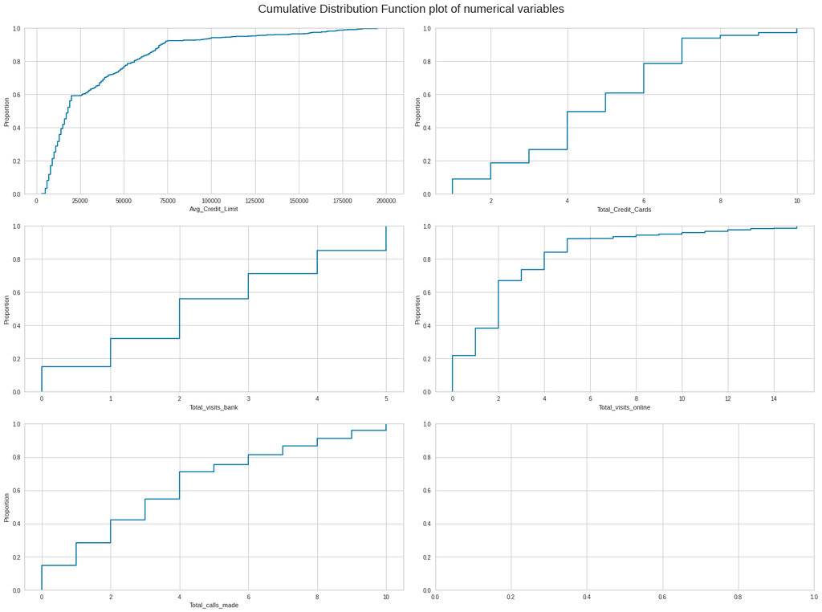

```python
#make subplots of the general distribution of each feature
num_col = ['Avg_Credit_Limit','Total_Credit_Cards','Total_visits_bank','Total_visits_online','Total_calls_made']

fig, axes = plt.subplots(3, 2, figsize=(20, 15))
fig.suptitle("Cumulative Distribution Function plot of numerical variables", fontsize=20)

counter = 0
for ii in range(3):
    sns.ecdfplot(ax=axes[ii][0], x=ALB_df[num_col[counter]])
    counter = counter + 1
    if counter != 5:
        sns.ecdfplot(ax=axes[ii][1], x=ALB_df[num_col[counter]])
        counter = counter + 1
    else:
        pass

fig.tight_layout(pad=2.0)
```

The above subplots are CUMULATIVE distributions.

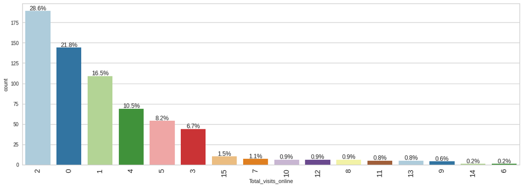

```python
# let's explore Total_visits_online further
labeled_barplot(ALB_df, "Total_visits_online", perc=True)
```

- 28.5% of customers do 2 online visits, 21.7% do 0 online visits, 16.5% do 1 online visit, and 25.4% do between 3 to 5.
- Notice that 1.5% do 15 online visits

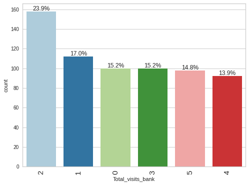

```python
# let's explore Total_visits_bank further
labeled_barplot(ALB_df, "Total_visits_bank", perc=True)
```

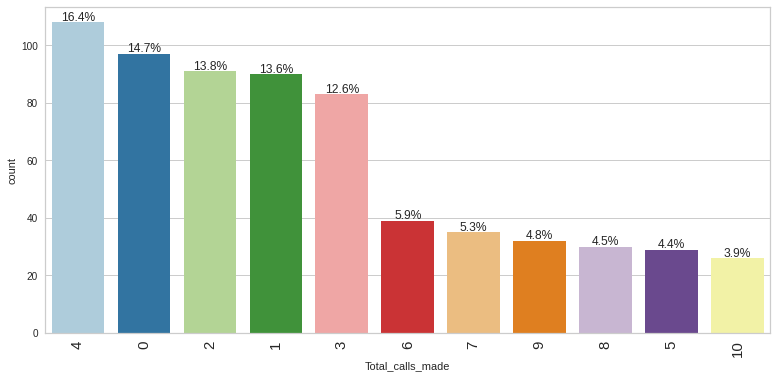

```python
# let's explore Total_calls_made further
labeled_barplot(ALB_df, "Total_calls_made", perc=True)
```

- The largest bin 4 calls is 16% of customers.
- 14.8% do 0 calls
- Similarly split are 1, 2, and 3 calls for a total of 41%.
- All others 5 to 10 are between 6% ro 4%.
- Notice that 10 calls are the smaller group and that each bin from from 5 to 10 calls are much smaller than the bin representing 3 calls.
- The majority of customers call between 0 to 4 times.

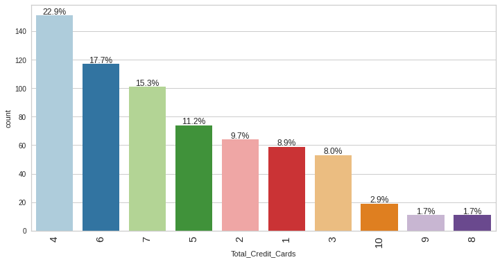

```python
# let's explore Total_Credit_Cards further
labeled_barplot(ALB_df, "Total_Credit_Cards", perc=True)
```

- 4 credit cards is the largest bin.
- 10, 9, 8 credit cards are the smallest bins, and they are significantly maller than other bins.
- 4,6,7 are significantly larger than other bins.

### **Outlier Treatment**

We observed during our univariate analysis that outliers represent valid entries for a bank business environment.

If we would drop these outliers we will be not considering these type of customers.

Therefore, we will keep outliers in our data.

## **Bivariate Analysis**

Lets perform a bivariate analysis.

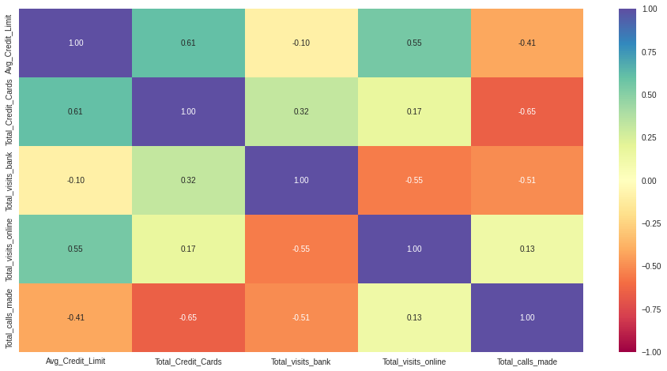

```python
plt.figure(figsize=(16, 8))
sns.heatmap(ALB_df[num_col].corr(), annot=True, vmin=-1, vmax=1, fmt=".2f", cmap="Spectral")
plt.show()
```

**Number of Credit Cards vs Contact with the ALB**

**Type of Contacts vs Other Type of Contacts with ALB**

**Credit Limit vs Number of Credit Cards

- Total_Credit_Cards and Avg_Credit_Limit have a correlation of 0.61, second highest. This was expected because probably the more credit cards, the larger the credit limit.

**Credit Limit vs Contaacts with ALB

- Total_calls_made and Avg_Credit_Limit have a correlation of 0.42 which is strong but less than Total_Credit_Cards and Total_calls_made (0.65). This may mean that more calls are made due to the number of credit cards than due to a larger credit limit.
- Total_visits_oline and Avg_Credit_Limit has a high correlation of 0.55. This may mean that a higher credit limit means that customer may make more online visits.
- Total_visits_bank and Avg_Credit_Limit has a correlation of 0.10, which is the lowest of all. This may mean that afterall, most customers with higher credit limit solved their problems, issues with other types of communications (calls or online).

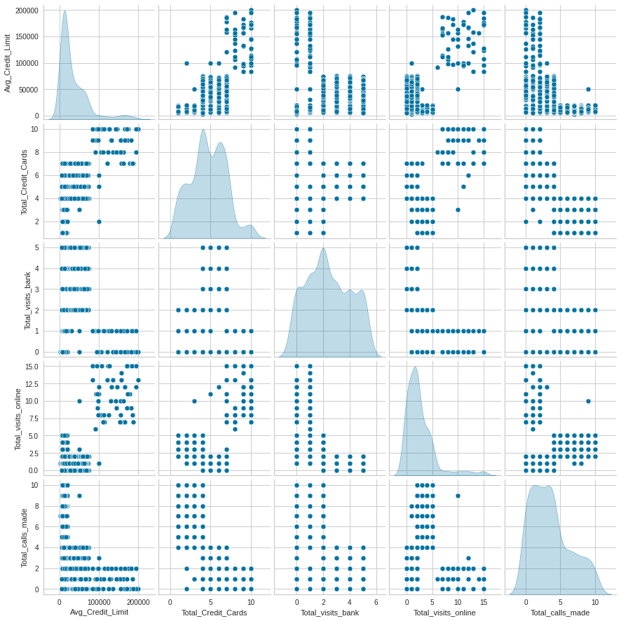

```python
#visualize pair plots
sns.pairplot(data=ALB_df[num_col], diag_kind="kde")
plt.show()
```

Many interesting things can be observed from the pairplots above to compliment the observations made from the heatmap shown before.

- As expected, most customers have lower credit limits and there are only a few that have higher credit limits. However, those outliers are valid because in any bank there will be banks with extraordinary credit limits, more so in this case where many customers have several credit cards.
- Customers with the highest avg credit limits have consistently more credit cards between 5 to 10.
- Customers that visit the bank less have higher credit limit. Is this because the bank gives them more importance?
- Customers with higher credit limits consistently do more online visits than customers with lower credit limits.
- consistently customers call the bank between 0 to 3 times.

Notice that it is difficult to guess the number of clusters from the pairplots because the plots are not very similar. For example Avg_Credit_Limit may hint 3 clusters, but Total_Credit_Cards may hint 4 clusters. Then Total_visits_bank may hint 6 clusters, Total_visits_online may hint 4 clusters, and Total_calls_made may hint 3 clusters.

## **Data Arrangement for Classification**

```python
#variables used for clustering
num_col
```

```
['Avg_Credit_Limit',
 'Total_Credit_Cards',
 'Total_visits_bank',
 'Total_visits_online',
 'Total_calls_made']
```

**Scaling Data**

```python
# scaling the dataset before clustering
scaler = StandardScaler()

#make a copy of the previously processed data. Keep in mind then:
#ALB_orig_df is the original data
#ALB_df is the processed data treated against duplicates, null values, missing values,
#dropped features before scaling
#ALB_scaled is the scaled dataset

ALB_scaled = scaler.fit_transform(ALB_df)
```

```python
# creating a dataframe of the scaled columns
ALB_scaled_df = pd.DataFrame(ALB_scaled, columns=ALB_df.columns)
```

```python
#The scaled data
ALB_scaled_df.head(10)
```

|  | Avg_Credit_Limit | Total_Credit_Cards | Total_visits_bank | Total_visits_online | Total_calls_made |
| --- | --- | --- | --- | --- | --- |
| 0 | 1.740 | -1.249 | -0.860 | -0.547 | -1.252 |
| 1 | 0.410 | -0.788 | -1.474 | 2.521 | 1.892 |
| 2 | 0.410 | 1.059 | -0.860 | 0.134 | 0.146 |
| 3 | -0.122 | 0.136 | -0.860 | -0.547 | 0.146 |
| 4 | 1.740 | 0.597 | -1.474 | 3.202 | -0.204 |
| 5 | -0.388 | -0.788 | -1.474 | -0.547 | 1.543 |
| 6 | 1.740 | 0.136 | -1.474 | 2.861 | -0.553 |
| 7 | -0.521 | -0.788 | -1.474 | -0.547 | -0.902 |
| 8 | -0.787 | -1.249 | -1.474 | -0.207 | -0.553 |
| 9 | -0.840 | -0.326 | -1.474 | -0.547 | 1.193 |

So what happens if we use zscore instead of StandardScaler()?

```python
#Lets apply(zscore) to check the difference with StandardScaler()
ALB_scaled_z_df =ALB_df.apply(zscore)
ALB_scaled_z_df.head(10)
```

|  | Avg_Credit_Limit | Total_Credit_Cards | Total_visits_bank | Total_visits_online | Total_calls_made |
| --- | --- | --- | --- | --- | --- |
| 0 | 1.740 | -1.249 | -0.860 | -0.547 | -1.252 |
| 1 | 0.410 | -0.788 | -1.474 | 2.521 | 1.892 |
| 2 | 0.410 | 1.059 | -0.860 | 0.134 | 0.146 |
| 3 | -0.122 | 0.136 | -0.860 | -0.547 | 0.146 |
| 4 | 1.740 | 0.597 | -1.474 | 3.202 | -0.204 |
| 5 | -0.388 | -0.788 | -1.474 | -0.547 | 1.543 |
| 6 | 1.740 | 0.136 | -1.474 | 2.861 | -0.553 |
| 7 | -0.521 | -0.788 | -1.474 | -0.547 | -0.902 |
| 8 | -0.787 | -1.249 | -1.474 | -0.207 | -0.553 |
| 9 | -0.840 | -0.326 | -1.474 | -0.547 | 1.193 |

As you can see above, using StandardScaler or apply(zscore) both scale the data equally (actually StandardScaler applies zscore).

Keep in mind:

\begin{align} Z = \frac{(X-\mu)}{\sigma}\end{align}

```python
ALB_scaled_df.describe().T
```

|  | count | mean | std | min | 25% | 50% | 75% | max |
| --- | --- | --- | --- | --- | --- | --- | --- | --- |
| Avg_Credit_Limit | 660.000 | 0.000 | 1.001 | -0.840 | -0.654 | -0.441 | 0.357 | 4.400 |
| Total_Credit_Cards | 660.000 | 0.000 | 1.001 | -1.711 | -0.788 | 0.136 | 0.597 | 2.444 |
| Total_visits_bank | 660.000 | -0.000 | 1.001 | -1.474 | -0.860 | -0.247 | 0.979 | 1.593 |
| Total_visits_online | 660.000 | 0.000 | 1.001 | -0.888 | -0.547 | -0.207 | 0.475 | 4.225 |
| Total_calls_made | 660.000 | -0.000 | 1.001 | -1.252 | -0.902 | -0.204 | 0.495 | 2.241 |

statistics after normalizing the data.

## **K-means Classification Modeling**

Using K-means algorithm, we will cluster the data by trying to separate samples in groups of equal variance, minimizing the intra-cluster square errors, that is minimizing the within-cluster sum-of-squares.

### **Elbow curve method**

Using the elbow curve to guess the number of clusters.

```
Number of Clusters: 1 	Average Distortion: 2.006922226250361
Number of Clusters: 2 	Average Distortion: 1.4571553548514269
Number of Clusters: 3 	Average Distortion: 1.1466276549150365
Number of Clusters: 4 	Average Distortion: 1.0463825294774465
Number of Clusters: 5 	Average Distortion: 0.9908683849620168
Number of Clusters: 6 	Average Distortion: 0.9430843103448057
Number of Clusters: 7 	Average Distortion: 0.9094246068442045
Number of Clusters: 8 	Average Distortion: 0.8887065275494689
Number of Clusters: 9 	Average Distortion: 0.8632252907059607
```

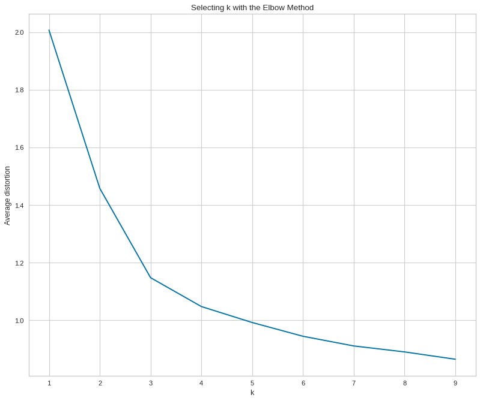

```python
clusters = range(1, 10)
meanDistortions = []

for k in clusters:
    model = KMeans(n_clusters=k)
    model.fit(ALB_scaled_df)
    prediction = model.predict(ALB_scaled_df)
    distortion = (
        sum(
            np.min(cdist(ALB_scaled_df, model.cluster_centers_, "euclidean"), axis=1)
        )
        / ALB_scaled_df.shape[0]
    )

    meanDistortions.append(distortion)

    print("Number of Clusters:", k, "\tAverage Distortion:", distortion)
plt.figure(figsize=(12, 10), dpi=80)
plt.plot(clusters, meanDistortions, "bx-")
plt.xlabel("k")
plt.ylabel("Average distortion")
plt.title("Selecting k with the Elbow Method")
plt.show()
```

Notice sharp bents at 2, 3, 4, 6, and 7. The bent as 3 looks the most relevant.

### **Silhouette scores**

The silhouette scores are computed as follows:

\begin{align} Silhouette Score = \frac{(b-a)}{max(a,b)}\end{align}

where

b: mean nearest-cluster distance (distance between a sample and the nearest cluster that the sample is not a part of).

a: mean intra-cluster distance

```
For n_clusters = 2, the silhouette score is 0.41842496663215445)
For n_clusters = 3, the silhouette score is 0.5157182558881063)
For n_clusters = 4, the silhouette score is 0.3556670619372605)
For n_clusters = 5, the silhouette score is 0.2717470361089752)
For n_clusters = 6, the silhouette score is 0.25516863727620004)
For n_clusters = 7, the silhouette score is 0.24809453254847574)
For n_clusters = 8, the silhouette score is 0.22736445234896802)
For n_clusters = 9, the silhouette score is 0.2217203577993332)
```

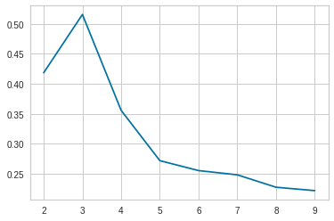

```python
sil_score = []
cluster_list = list(range(2, 10))
for n_clusters in cluster_list:
    clusterer = KMeans(n_clusters=n_clusters)
    preds = clusterer.fit_predict((ALB_scaled_df))
    # centers = clusterer.cluster_centers_
    score = silhouette_score(ALB_scaled_df, preds)
    sil_score.append(score)
    print("For n_clusters = {}, the silhouette score is {})".format(n_clusters, score))

plt.plot(cluster_list, sil_score)
plt.show()
```

The silhouette score for n_clusters= 3 clusters is 0.516. The silhouette score for n_clusters= 4 is 0.357. The silhouette score for n_clusters= 2 is 0.418.

A high silhouette score is an indication of how dense the clusters are, so we are looking for values closer to 1 (and farther from -1 which represents a completely incorrect cluster). The associated n_cluster should be an ideal k value.

So in this case, k =3 has the highest silhouette score so we will begin by considering k=3 and later compare to the next Ks with the highest silhouette scores (2 and 4).

**Visualize the Clusters silhouettes**

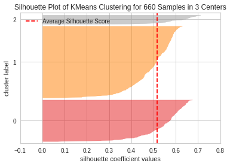

```python
# finding optimal no. of clusters with silhouette coefficients k=3
visualizer = SilhouetteVisualizer(KMeans(3, random_state=1))
visualizer.fit(ALB_scaled_df)
visualizer.show()
```

The average silhouette score for K=3 is somewhere around 0.52.

For K=3 clusters 0, 1, and 2 are within the average silhouette score, being cluster 2 the most cohesive and cluster 0 being more cohesive than cluster 1.

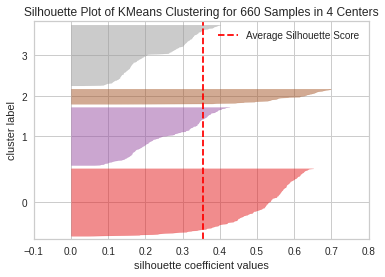

```python
# finding optimal no. of clusters with silhouette coefficients k=4
visualizer = SilhouetteVisualizer(KMeans(4, random_state=1))
visualizer.fit(ALB_scaled_df)
visualizer.show()
```

The average silhouette score for K=4 is somewhere around 0.36.

For K=4 clusters 0, 1, 2, and 3 are within the average silhouette score, being cluster 2 the most cohesive and cluster 0 being more cohesive than cluster 1 and 3.

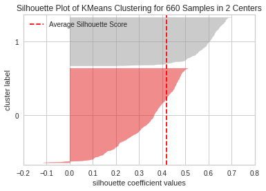

```python
# finding optimal no. of clusters with silhouette coefficients k=2
visualizer = SilhouetteVisualizer(KMeans(2, random_state=1))
visualizer.fit(ALB_scaled_df)
visualizer.show()
```

The average silhouette score for K=2 is somewhere around 0.42.

Overall, the two clusters are not well balanced as we can see that cluster 0 is much wider than cluster 1.

Comparing the three silhouette plots for K=2, 3, and 4, although the clusters in each K fall within the average silhouette scores, the plot for K=3 shows clusters that are better balanced.

```python
#since we are going to compare our results for different ks, lets make different
#dataframes for each k
ALB_k3_df = ALB_df.copy()
ALB_scaled_k3_df = ALB_scaled_df.copy()

ALB_k4_df = ALB_df.copy()
ALB_scaled_k4_df = ALB_scaled_df.copy()

ALB_k2_df = ALB_df.copy()
ALB_scaled_k2_df = ALB_scaled_df.copy()
```

### **Cluster profiling**

Note: We may be referring to Clusters as Segments or Groups within this notebook.

**K=3 Clusters**

```python
# let's take 3 as number of clusters
kmeans_k3 = KMeans(n_clusters=3, random_state=1)
kmeans_k3.fit(ALB_scaled_k3_df)
prediction_k3 = kmeans_k3.predict(ALB_scaled_k3_df)
```

```python
# adding kmeans cluster labels to the original and scaled dataframes
ALB_k3_df["SEGMENT"] = prediction_k3
ALB_scaled_k3_df["SEGMENT"] = prediction_k3
print("SEGMENTS Assigned : \n")
ALB_k3_df.head(20)
```

```
SEGMENTS Assigned :
```

|  | Avg_Credit_Limit | Total_Credit_Cards | Total_visits_bank | Total_visits_online | Total_calls_made | SEGMENT |
| --- | --- | --- | --- | --- | --- | --- |
| 0 | 100000 | 2 | 1 | 1 | 0 | 1 |
| 1 | 50000 | 3 | 0 | 10 | 9 | 0 |
| 2 | 50000 | 7 | 1 | 3 | 4 | 1 |
| 3 | 30000 | 5 | 1 | 1 | 4 | 1 |
| 4 | 100000 | 6 | 0 | 12 | 3 | 2 |
| 5 | 20000 | 3 | 0 | 1 | 8 | 0 |
| 6 | 100000 | 5 | 0 | 11 | 2 | 2 |
| 7 | 15000 | 3 | 0 | 1 | 1 | 0 |
| 8 | 5000 | 2 | 0 | 2 | 2 | 0 |
| 9 | 3000 | 4 | 0 | 1 | 7 | 0 |
| 10 | 10000 | 4 | 0 | 5 | 5 | 0 |
| 11 | 13000 | 3 | 0 | 2 | 7 | 0 |
| 12 | 11000 | 1 | 2 | 5 | 9 | 0 |
| 13 | 9000 | 1 | 1 | 5 | 6 | 0 |
| 14 | 6000 | 2 | 2 | 4 | 6 | 0 |
| 15 | 8000 | 2 | 0 | 5 | 7 | 0 |
| 16 | 15000 | 2 | 1 | 2 | 4 | 0 |
| 17 | 8000 | 2 | 0 | 3 | 4 | 0 |
| 18 | 11000 | 2 | 2 | 2 | 7 | 0 |
| 19 | 19000 | 4 | 1 | 5 | 8 | 0 |

```python
#Averages for each feature when k=3
cluster_profile_k3 = ALB_k3_df.groupby("SEGMENT").mean()
```

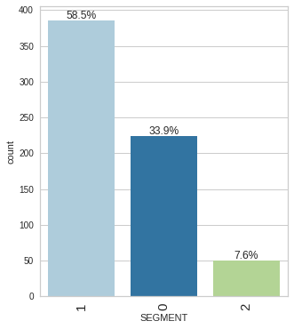

```python
#plot counts for each segment
labeled_barplot(ALB_scaled_k3_df, "SEGMENT", perc=True, n=None)
```

58% of customers are clustered in Segment 1, only 7.7% are clustered in Segment 2.

```python
cluster_profile_k3["count_in_each_segments"] = (
    ALB_k3_df.groupby("SEGMENT")["Avg_Credit_Limit"].count().values
)
```

```python
# let's display cluster profiles
cluster_profile_k3.style.highlight_max(color="darkgreen", axis=0)
```

| SEGMENT | Avg_Credit_Limit | Total_Credit_Cards | Total_visits_bank | Total_visits_online | Total_calls_made | count_in_each_segments |
| --- | --- | --- | --- | --- | --- | --- |
| 0 | 12174.107143 | 2.410714 | 0.933036 | 3.553571 | 6.870536 | 224 |
| 1 | 33782.383420 | 5.515544 | 3.489637 | 0.981865 | 2.000000 | 386 |
| 2 | 141040.000000 | 8.740000 | 0.600000 | 10.900000 | 1.080000 | 50 |

Notice that cluster 2 has the highest average credit limit, the highest average total credit cards and the highest average total visits online. Also, it has the lowest total visits bank, the lowest total calls made and it is the smallest cluster with 50 points.

Cluster 1 has the largest total visits bank and it is the largest cluster. It has the second largest Avg_Credit_Limit and the second largest Total_Credit_Cards.

Cluster 0 has the largest total calls made, the smallest Avg_Credit_Limit and the smallest Total_Credit_Cards. It is the second largest group.

So would Segment 2 be ALB "Super VIP", Segment 1 be "VIP" and Segment 0 be "Standard" customers?

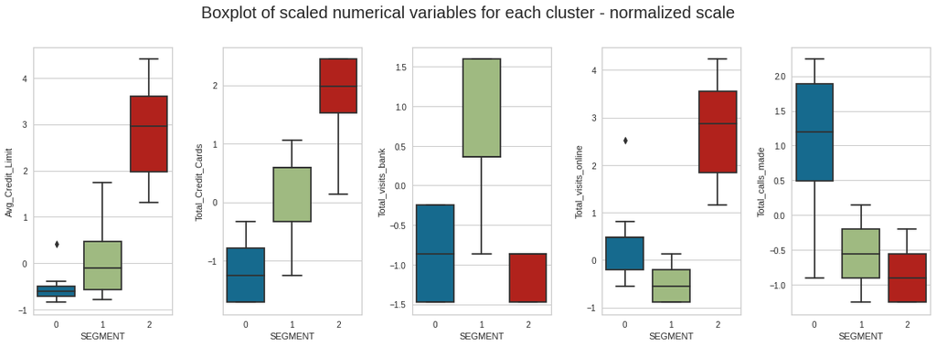

```python
#visualize the boxplots for each segment for each feature for the scaled data.
fig, axes = plt.subplots(1, 5, figsize=(16, 6))
fig.suptitle("Boxplot of scaled numerical variables for each cluster - normalized scale", fontsize=20)
counter = 0
for ii in range(5):
    sns.boxplot(
        ax=axes[ii],
        y=ALB_scaled_k3_df[num_col[counter]],
        x=ALB_scaled_k3_df["SEGMENT"],
    )
    counter = counter + 1

fig.tight_layout(pad=2.0)
```

Notice that when k=3, segments for Total_Credit_Cards, Total_visits_online and Avg_Credit_Limit are clearly separated.

Total_visits_bank is not separated between Segment 0 and 2, but segment 1 is well separated. In fact, segment 0 contain all the values present in segment 0.

Total_calls_bank segment 0 is separated well from segment 1 and 2, but segment 1 and 2 have values in common.

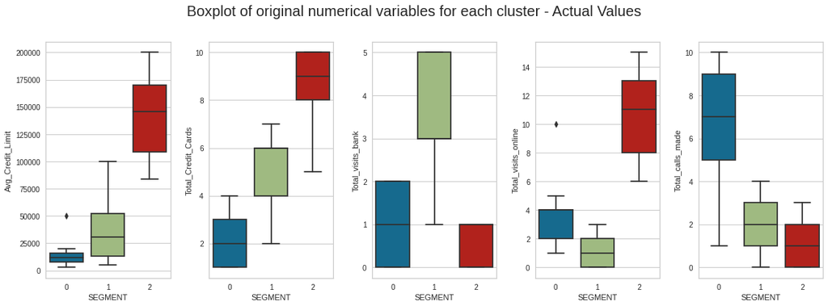

```python
#visualize the boxplots for each segment for each feature for the data represented
#with actual values.
fig, axes = plt.subplots(1, 5, figsize=(16, 6))
fig.suptitle("Boxplot of original numerical variables for each cluster - Actual Values", fontsize=20)
counter = 0
for ii in range(5):
    sns.boxplot(ax=axes[ii], y=ALB_k3_df[num_col[counter]], x=ALB_k3_df["SEGMENT"])
    counter = counter + 1

fig.tight_layout(pad=2.0)
```

The plot above is actually the same plot for normalized values, but the values shown are the actual values.

```python
#crosstable for Total_Credit_Cards per segment
pd.crosstab(ALB_k3_df.SEGMENT, ALB_k3_df.Total_Credit_Cards).style.highlight_max(
    color="darkgreen", axis=0
)
```

| Total_Credit_Cards SEGMENT | 1 | 2 | 3 | 4 | 5 | 6 | 7 | 8 | 9 | 10 |
| --- | --- | --- | --- | --- | --- | --- | --- | --- | --- | --- |
| 0 | 59 | 63 | 53 | 49 | 0 | 0 | 0 | 0 | 0 | 0 |
| 1 | 0 | 1 | 0 | 102 | 73 | 116 | 94 | 0 | 0 | 0 |
| 2 | 0 | 0 | 0 | 0 | 1 | 1 | 7 | 11 | 11 | 19 |

We can see that in general, the segments are very well separated as we had already concluded from the Total_Credit_Cards boxplot.

```python
#Cross table for Avg_Credit_Limit per segment
pd.crosstab(ALB_k3_df.SEGMENT, ALB_k3_df.Avg_Credit_Limit).style.highlight_max(
    color="darkgreen", axis=0
)
```

| Avg_Credit_Limit SEGMENT | 3000 | 5000 | 6000 | 7000 | 8000 | 9000 | 10000 | 11000 | 12000 | 13000 | 14000 | 15000 | 16000 | 17000 | 18000 | 19000 | 20000 | 25000 | 26000 | 27000 | 28000 | 29000 | 30000 | 31000 | 32000 | 33000 | 34000 | 35000 | 36000 | … |
| --- | --- | --- | --- | --- | --- | --- | --- | --- | --- | --- | --- | --- | --- | --- | --- | --- | --- | --- | --- | --- | --- | --- | --- | --- | --- | --- | --- | --- | --- | --- |
| 0 | 1 | 13 | 17 | 13 | 20 | 18 | 14 | 15 | 8 | 18 | 14 | 11 | 13 | 13 | 9 | 13 | 13 | 0 | 0 | 0 | 0 | 0 | 0 | 0 | 0 | 0 | 0 | 0 | 0 | … |
| 1 | 0 | 8 | 14 | 11 | 15 | 10 | 12 | 9 | 10 | 10 | 9 | 6 | 9 | 10 | 14 | 13 | 7 | 1 | 5 | 2 | 3 | 5 | 6 | 5 | 2 | 4 | 6 | 2 | 11 | … |
| 2 | 0 | 0 | 0 | 0 | 0 | 0 | 0 | 0 | 0 | 0 | 0 | 0 | 0 | 0 | 0 | 0 | 0 | 0 | 0 | 0 | 0 | 0 | 0 | 0 | 0 | 0 | 0 | 0 | 0 | … |

The above cross table is too large to be visualized in our output. Therefore, lets flip the axis.

```python
#crosstable for Avg_Credit_Limit for each segment
pd.crosstab(ALB_k3_df.Avg_Credit_Limit, ALB_k3_df.SEGMENT).style.highlight_max(
    color="darkgreen", axis=1
)
```

| SEGMENT Avg_Credit_Limit | 0 | 1 | 2 |
| --- | --- | --- | --- |
| 3000 | 1 | 0 | 0 |
| 5000 | 13 | 8 | 0 |
| 6000 | 17 | 14 | 0 |
| 7000 | 13 | 11 | 0 |
| 8000 | 20 | 15 | 0 |
| 9000 | 18 | 10 | 0 |
| 10000 | 14 | 12 | 0 |
| 11000 | 15 | 9 | 0 |
| 12000 | 8 | 10 | 0 |
| 13000 | 18 | 10 | 0 |
| 14000 | 14 | 9 | 0 |
| 15000 | 11 | 6 | 0 |
| 16000 | 13 | 9 | 0 |
| 17000 | 13 | 10 | 0 |
| 18000 | 9 | 14 | 0 |
| 19000 | 13 | 13 | 0 |
| 20000 | 13 | 7 | 0 |
| 25000 | 0 | 1 | 0 |
| 26000 | 0 | 5 | 0 |
| 27000 | 0 | 2 | 0 |
| 28000 | 0 | 3 | 0 |
| 29000 | 0 | 5 | 0 |
| 30000 | 0 | 6 | 0 |
| 31000 | 0 | 5 | 0 |
| 32000 | 0 | 2 | 0 |
| 33000 | 0 | 4 | 0 |
| 34000 | 0 | 6 | 0 |
| 35000 | 0 | 2 | 0 |
| 36000 | 0 | 11 | 0 |
| 37000 | 0 | 6 | 0 |

[output cut: 80 more lines]

Consistently, higher avg credit limits above \$84,000 are grouped in Segment 2. Segment 1 consistently has the avg credit limit between \$25,000 to \$75,000 but also contain lower avg credit limits that make up cluster 0.

```python
#crosstable for Total_visits_bank per segment
pd.crosstab(ALB_k3_df.SEGMENT, ALB_k3_df.Total_visits_bank).style.highlight_max(
    color="darkgreen", axis=0
)
```

| Total_visits_bank SEGMENT | 0 | 1 | 2 | 3 | 4 | 5 |
| --- | --- | --- | --- | --- | --- | --- |
| 0 | 80 | 79 | 65 | 0 | 0 | 0 |
| 1 | 0 | 3 | 93 | 100 | 92 | 98 |
| 2 | 20 | 30 | 0 | 0 | 0 | 0 |

```python
#cross table for Total_visits_online per segment
pd.crosstab(ALB_k3_df.SEGMENT, ALB_k3_df.Total_visits_online).style.highlight_max(
    color="darkgreen", axis=0
)
```

| Total_visits_online SEGMENT | 0 | 1 | 2 | 3 | 4 | 5 | 6 | 7 | 8 | 9 | 10 | 11 | 12 | 13 | 14 | 15 |
| --- | --- | --- | --- | --- | --- | --- | --- | --- | --- | --- | --- | --- | --- | --- | --- | --- |
| 0 | 0 | 3 | 54 | 43 | 69 | 54 | 0 | 0 | 0 | 0 | 1 | 0 | 0 | 0 | 0 | 0 |
| 1 | 144 | 106 | 135 | 1 | 0 | 0 | 0 | 0 | 0 | 0 | 0 | 0 | 0 | 0 | 0 | 0 |
| 2 | 0 | 0 | 0 | 0 | 0 | 0 | 1 | 7 | 6 | 4 | 5 | 5 | 6 | 5 | 1 | 10 |

```python
# Cross table for Total_calls_made per segment
pd.crosstab(ALB_k3_df.SEGMENT, ALB_k3_df.Total_calls_made).style.highlight_max(
    color="darkgreen", axis=0
)
```

| Total_calls_made SEGMENT | 0 | 1 | 2 | 3 | 4 | 5 | 6 | 7 | 8 | 9 | 10 |
| --- | --- | --- | --- | --- | --- | --- | --- | --- | --- | --- | --- |
| 0 | 0 | 1 | 1 | 0 | 31 | 29 | 39 | 35 | 30 | 32 | 26 |
| 1 | 81 | 74 | 72 | 82 | 77 | 0 | 0 | 0 | 0 | 0 | 0 |
| 2 | 16 | 15 | 18 | 1 | 0 | 0 | 0 | 0 | 0 | 0 | 0 |

Segment 0 is well separated from the other segments. However, Segment 1 and 2 are not well separated.

**Visualize the Clusters k = 3**

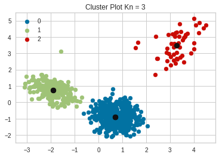

```python
#Function to visualize the clusters using pca
#PCA is done inside the visualize_clusters function (Refer to the section FUNCTIONS
#to see how this was implemented)

visualize_clusters(ALB_scaled_k3_df, 5, 3)
```

Overall, when K=3, the clusters are well separated.

We also know how the Cluster Profile is when K=3.

**K=4 Clusters**

Lets see what happens when K=4 was chosen instead. We will not comment every result but focus on the cluster plot. We have seen in the silhouette plot that K=4 has clusters that are less balanced than the case for K=3. We already know that the silhouette score for K=4 is less than the silhouette score for K=3.

```python
# let's take 4 as number of clusters
kmeans_k4 = KMeans(n_clusters=4, random_state=1)
kmeans_k4.fit(ALB_scaled_k4_df)
prediction_k4 = kmeans_k4.predict(ALB_scaled_k4_df)
```

```python
# adding kmeans cluster labels to the original and scaled dataframes
ALB_k4_df["SEGMENT"] = prediction_k4
ALB_scaled_k4_df["SEGMENT"] = prediction_k4
print("SEGMENTS Assigned : \n")
ALB_k4_df.head(20)
```

```
SEGMENTS Assigned :
```

|  | Avg_Credit_Limit | Total_Credit_Cards | Total_visits_bank | Total_visits_online | Total_calls_made | SEGMENT |
| --- | --- | --- | --- | --- | --- | --- |
| 0 | 100000 | 2 | 1 | 1 | 0 | 3 |
| 1 | 50000 | 3 | 0 | 10 | 9 | 0 |
| 2 | 50000 | 7 | 1 | 3 | 4 | 3 |
| 3 | 30000 | 5 | 1 | 1 | 4 | 3 |
| 4 | 100000 | 6 | 0 | 12 | 3 | 2 |
| 5 | 20000 | 3 | 0 | 1 | 8 | 0 |
| 6 | 100000 | 5 | 0 | 11 | 2 | 2 |
| 7 | 15000 | 3 | 0 | 1 | 1 | 3 |
| 8 | 5000 | 2 | 0 | 2 | 2 | 0 |
| 9 | 3000 | 4 | 0 | 1 | 7 | 0 |
| 10 | 10000 | 4 | 0 | 5 | 5 | 0 |
| 11 | 13000 | 3 | 0 | 2 | 7 | 0 |
| 12 | 11000 | 1 | 2 | 5 | 9 | 0 |
| 13 | 9000 | 1 | 1 | 5 | 6 | 0 |
| 14 | 6000 | 2 | 2 | 4 | 6 | 0 |
| 15 | 8000 | 2 | 0 | 5 | 7 | 0 |
| 16 | 15000 | 2 | 1 | 2 | 4 | 0 |
| 17 | 8000 | 2 | 0 | 3 | 4 | 0 |
| 18 | 11000 | 2 | 2 | 2 | 7 | 0 |
| 19 | 19000 | 4 | 1 | 5 | 8 | 0 |

```python
#create a cluster profile
cluster_profile_k4 = ALB_k4_df.groupby("SEGMENT").mean()
```

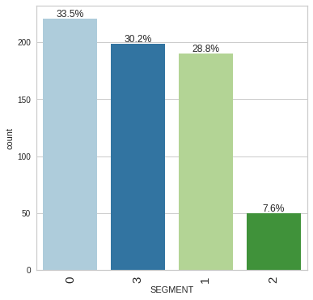

```python
#plot counts for each segment
labeled_barplot(ALB_scaled_k4_df, "SEGMENT", perc=True, n=None)
```

```python
#Group the segments
cluster_profile_k4["Segment_Count"] = (
    ALB_k4_df.groupby("SEGMENT")["Avg_Credit_Limit"].count().values
)
```

```python
# let's display cluster profiles
cluster_profile_k4.style.highlight_max(color="darkgreen", axis=0)
```

| SEGMENT | Avg_Credit_Limit | Total_Credit_Cards | Total_visits_bank | Total_visits_online | Total_calls_made | Segment_Count |
| --- | --- | --- | --- | --- | --- | --- |
| 0 | 12167.420814 | 2.393665 | 0.927602 | 3.574661 | 6.923077 | 221 |
| 1 | 31226.315789 | 5.478947 | 4.515789 | 1.010526 | 1.936842 | 190 |
| 2 | 141040.000000 | 8.740000 | 0.600000 | 10.900000 | 1.080000 | 50 |
| 3 | 35904.522613 | 5.522613 | 2.477387 | 0.969849 | 2.075377 | 199 |

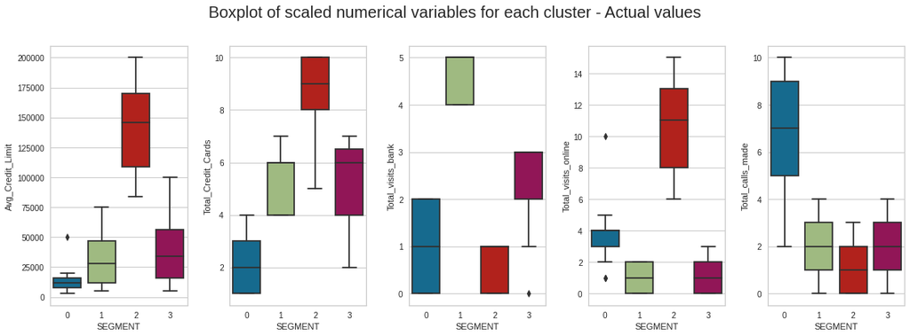

```python
#visualize the boxplots for each segment and feature
fig, axes = plt.subplots(1, 5, figsize=(16, 6))
fig.suptitle("Boxplot of scaled numerical variables for each cluster - Actual values", fontsize=20)
counter = 0
for ii in range(5):
    sns.boxplot(
        ax=axes[ii],
        y=ALB_k4_df[num_col[counter]],
        x=ALB_k4_df["SEGMENT"],
    )
    counter = counter + 1

fig.tight_layout(pad=2.0)
```

Notice that the boxplots for K=4 aren't as well separated as for K=3.

```python
#Crosstable Avg_Credit_Limt per segments
pd.crosstab(ALB_k4_df.Avg_Credit_Limit, ALB_k4_df.SEGMENT ).style.highlight_max(
    color="darkgreen", axis=1
)
```

| SEGMENT Avg_Credit_Limit | 0 | 1 | 2 | 3 |
| --- | --- | --- | --- | --- |
| 3000 | 1 | 0 | 0 | 0 |
| 5000 | 13 | 4 | 0 | 4 |
| 6000 | 17 | 5 | 0 | 9 |
| 7000 | 12 | 7 | 0 | 5 |
| 8000 | 20 | 7 | 0 | 8 |
| 9000 | 18 | 9 | 0 | 1 |
| 10000 | 14 | 8 | 0 | 4 |
| 11000 | 15 | 5 | 0 | 4 |
| 12000 | 8 | 6 | 0 | 4 |
| 13000 | 18 | 7 | 0 | 3 |
| 14000 | 14 | 6 | 0 | 3 |
| 15000 | 10 | 5 | 0 | 2 |
| 16000 | 12 | 4 | 0 | 6 |
| 17000 | 13 | 6 | 0 | 4 |
| 18000 | 9 | 5 | 0 | 9 |
| 19000 | 13 | 3 | 0 | 10 |
| 20000 | 13 | 3 | 0 | 4 |
| 25000 | 0 | 0 | 0 | 1 |
| 26000 | 0 | 4 | 0 | 1 |
| 27000 | 0 | 0 | 0 | 2 |
| 28000 | 0 | 3 | 0 | 0 |
| 29000 | 0 | 2 | 0 | 3 |
| 30000 | 0 | 2 | 0 | 4 |
| 31000 | 0 | 3 | 0 | 2 |
| 32000 | 0 | 1 | 0 | 1 |
| 33000 | 0 | 2 | 0 | 2 |
| 34000 | 0 | 2 | 0 | 4 |
| 35000 | 0 | 0 | 0 | 2 |
| 36000 | 0 | 6 | 0 | 5 |
| 37000 | 0 | 4 | 0 | 2 |

[output cut: 80 more lines]

```python
#Crosstable Total_Credit_cards per segments
pd.crosstab(ALB_k4_df.SEGMENT, ALB_k4_df.Total_Credit_Cards).style.highlight_max(
    color="darkgreen", axis=0
)
```

| Total_Credit_Cards SEGMENT | 1 | 2 | 3 | 4 | 5 | 6 | 7 | 8 | 9 | 10 |
| --- | --- | --- | --- | --- | --- | --- | --- | --- | --- | --- |
| 0 | 59 | 63 | 52 | 47 | 0 | 0 | 0 | 0 | 0 | 0 |
| 1 | 0 | 0 | 0 | 55 | 33 | 58 | 44 | 0 | 0 | 0 |
| 2 | 0 | 0 | 0 | 0 | 1 | 1 | 7 | 11 | 11 | 19 |
| 3 | 0 | 1 | 1 | 49 | 40 | 58 | 50 | 0 | 0 | 0 |

```python
#Total_Visits_bank per segment
pd.crosstab(ALB_k4_df.SEGMENT, ALB_k4_df.Total_visits_bank).style.highlight_max(
    color="darkgreen", axis=0
)
```

| Total_visits_bank SEGMENT | 0 | 1 | 2 | 3 | 4 | 5 |
| --- | --- | --- | --- | --- | --- | --- |
| 0 | 79 | 79 | 63 | 0 | 0 | 0 |
| 1 | 0 | 0 | 0 | 0 | 92 | 98 |
| 2 | 20 | 30 | 0 | 0 | 0 | 0 |
| 3 | 1 | 3 | 95 | 100 | 0 | 0 |

Segment 1 is well separated from all other Segments. Segment 0 and 2 are not well separated and Separated from Segment 0.

```python
#Total_visits_online per segment
pd.crosstab(ALB_k4_df.SEGMENT, ALB_k4_df.Total_visits_online).style.highlight_max(
    color="darkgreen", axis=0
)
```

| Total_visits_online SEGMENT | 0 | 1 | 2 | 3 | 4 | 5 | 6 | 7 | 8 | 9 | 10 | 11 | 12 | 13 | 14 | 15 |
| --- | --- | --- | --- | --- | --- | --- | --- | --- | --- | --- | --- | --- | --- | --- | --- | --- |
| 0 | 0 | 2 | 53 | 42 | 69 | 54 | 0 | 0 | 0 | 0 | 1 | 0 | 0 | 0 | 0 | 0 |
| 1 | 72 | 44 | 74 | 0 | 0 | 0 | 0 | 0 | 0 | 0 | 0 | 0 | 0 | 0 | 0 | 0 |
| 2 | 0 | 0 | 0 | 0 | 0 | 0 | 1 | 7 | 6 | 4 | 5 | 5 | 6 | 5 | 1 | 10 |
| 3 | 72 | 63 | 62 | 2 | 0 | 0 | 0 | 0 | 0 | 0 | 0 | 0 | 0 | 0 | 0 | 0 |

```python
#Total_calls_made per segment
pd.crosstab(ALB_k4_df.SEGMENT, ALB_k4_df.Total_calls_made).style.highlight_max(
    color="darkgreen", axis=0
)
```

| Total_calls_made SEGMENT | 0 | 1 | 2 | 3 | 4 | 5 | 6 | 7 | 8 | 9 | 10 |
| --- | --- | --- | --- | --- | --- | --- | --- | --- | --- | --- | --- |
| 0 | 0 | 0 | 1 | 0 | 29 | 29 | 39 | 35 | 30 | 32 | 26 |
| 1 | 40 | 41 | 33 | 43 | 33 | 0 | 0 | 0 | 0 | 0 | 0 |
| 2 | 16 | 15 | 18 | 1 | 0 | 0 | 0 | 0 | 0 | 0 | 0 |
| 3 | 41 | 34 | 39 | 39 | 46 | 0 | 0 | 0 | 0 | 0 | 0 |

Segment 0 is very well separated from other segments The same can't be said about the other segments.

**Visualize** Clusters K=4

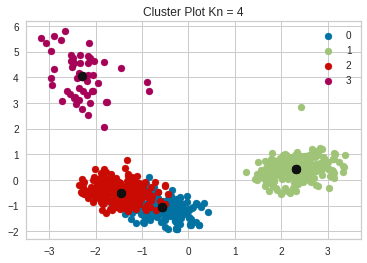

```python
#Function to visualize the clusters using pca
#PCA is done inside the visualize_clusters function (Refer to the section FUNCTIONS
#to see how this was implemented)

visualize_clusters(ALB_scaled_k4_df, 5, 4)
```